# BF_Finals 23

###### Do a Histogram plot of residuals. What does the plot indicate?

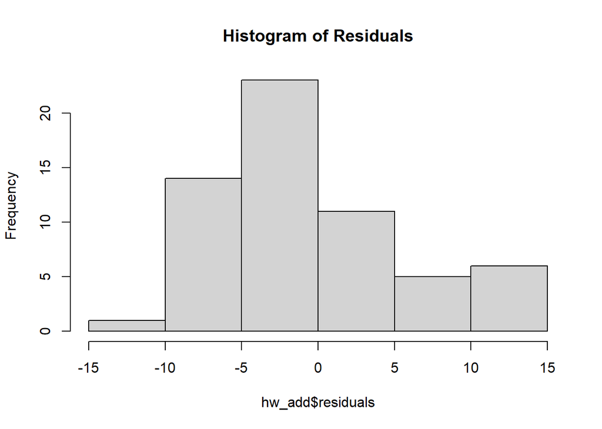

```r
hist(hw_add$residuals, main ='Histogram of Residuals')
```

- The histogram does appears to be normally distributed.
- The values have a mean zero.
- This means that the data is not biased as the mean is at zero.

###### Do a plot of fitted values vs. residuals. What does the plot indicate?

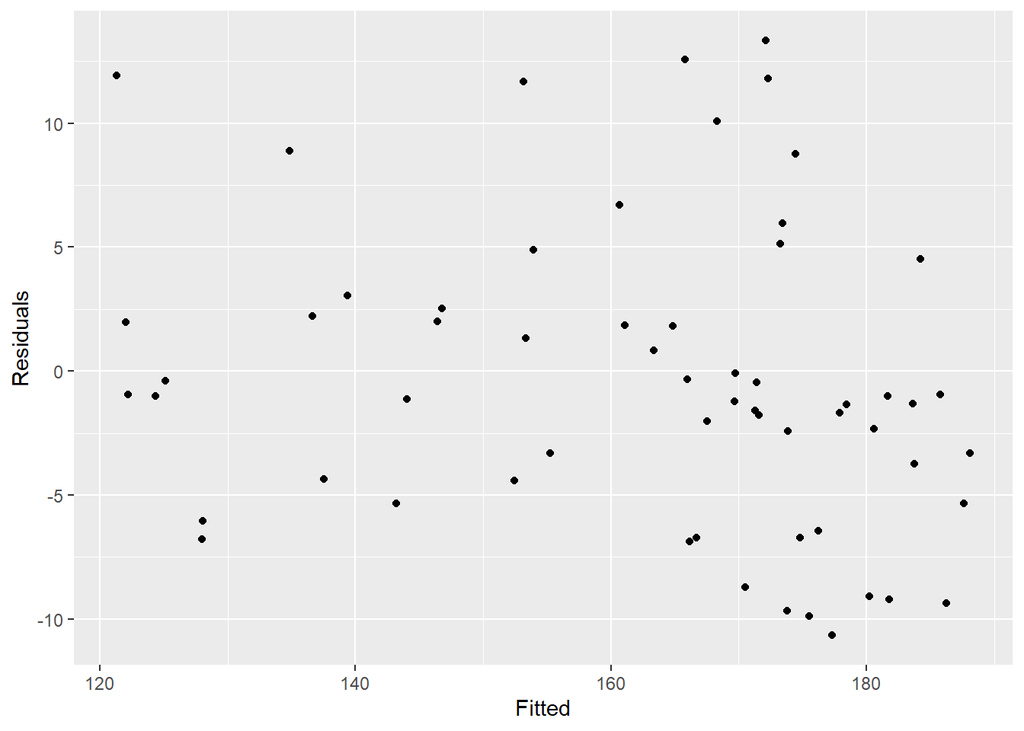

```r
cbind(Fitted = fitted(hw_add),
      Residuals=residuals(hw_add)) %>%
  as.data.frame() %>%
  ggplot(aes(x=Fitted, y=Residuals)) + geom_point()
```

- The Fitted vs Residuals plot appears to be random.
- This means there is NO heteroscedasticity in the errors which means that the variance of the residuals is constant.

###### Do a plot of actual values vs. residuals. What does the plot indicate?

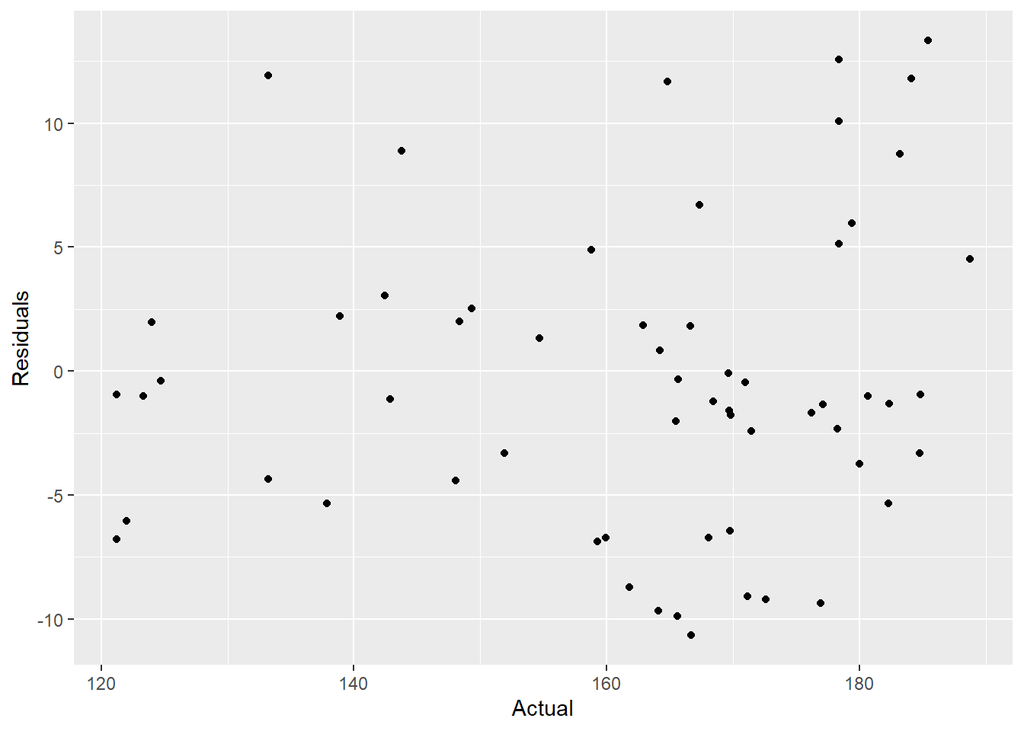

```r
cbind(Actual = TS_win,
      Residuals=residuals(hw_add)) %>%
  as.data.frame() %>%
  ggplot(aes(x=Actual, y=Residuals)) + geom_point()
```

- In this plot there seems to be pattern in Actuals and Residuals.

###### Do an ACF plot of the residuals? What does this plot indicate?

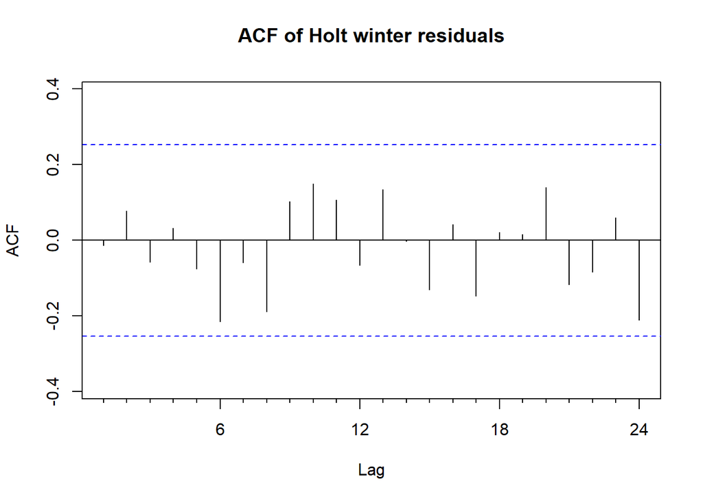

```r
Acf(hw_add$residuals, main = "ACF of Holt winter residuals")
```

- In the Acf plot, few of the values close the confidence levels but seems to be random, hence indicating that residual is random in nature.
- This signifies that the forecast is a good forecast.
- This proves to be the best forecast comparing all the previous ones tested.

## Print the 5 measures of accuracy for this forecasting technique

```r
hw_accuracy <- accuracy(hw_add)
hw_accuracy
```

```
##                     ME     RMSE      MAE        MPE     MAPE      MASE
## Training set -0.403236 6.139429 4.862737 -0.2999758 2.996916 0.2775832
##                     ACF1
## Training set -0.01395089
```

```r
summary(hw_add)
```

```
##
## Forecast method: Holt-Winters' additive method
##
## Model Information:
## Holt-Winters' additive method
##
## Call:
##  hw(y = TS_win, seasonal = "additive")
##
##   Smoothing parameters:
##     alpha = 0.9262
##     beta  = 0.0002
##     gamma = 0.0001
##
##   Initial states:
##     l = 121.6981
##     b = 1.5747
##     s = -5.2835 -4.7104 -3.8007 4.2063 4.4507 0.7968
##            4.4918 3.4419 -0.5184 -3.1621 1.166 -1.0784
##
##   sigma:  7.1693
##
##      AIC     AICc      BIC
## 497.4285 511.9999 533.0323
##
## Error measures:
##                     ME     RMSE      MAE        MPE     MAPE      MASE
## Training set -0.403236 6.139429 4.862737 -0.2999758 2.996916 0.2775832
##                     ACF1
## Training set -0.01395089
##
## Forecasts:
##          Point Forecast    Lo 80    Hi 80    Lo 95    Hi 95
## Dec 2023       194.1929 185.0050 203.3807 180.1413 208.2444
## Jan 2024       198.0070 185.4826 210.5315 178.8525 217.1616
## Feb 2024       195.2511 180.1074 210.3948 172.0908 218.4114
## Mar 2024       199.4645 182.0914 216.8376 172.8946 226.0344
## Apr 2024       204.9952 185.6473 224.3432 175.4051 234.5854
## May 2024       207.6176 186.4780 228.7573 175.2873 239.9479
## Jun 2024       205.4947 182.7033 228.2861 170.6383 240.3512
## Jul 2024       210.7186 186.3868 235.0504 173.5063 247.9309
## Aug 2024       212.0452 186.2644 237.8260 172.6169 251.4735
## Sep 2024       205.6099 178.4569 232.7629 164.0830 247.1368
## Oct 2024       206.2726 177.8131 234.7321 162.7476 249.7977
## Nov 2024       207.2689 177.5599 236.9780 161.8329 252.7050
## Dec 2024       213.0457 182.1369 243.9545 165.7748 260.3166
## Jan 2025       216.8599 184.7961 248.9236 167.8226 265.8971
## Feb 2025       214.1039 180.9250 247.2828 163.3612 264.8466
## Mar 2025       218.3173 184.0592 252.5754 165.9241 270.7105
## Apr 2025       223.8481 188.5434 259.1527 169.8543 277.8419
## May 2025       226.4704 190.1491 262.7918 170.9217 282.0192
## Jun 2025       224.3475 187.0368 261.6583 167.2857 281.4094
## Jul 2025       229.5715 191.2966 267.8463 171.0351 288.1078
## Aug 2025       230.8980 191.6824 270.1136 170.9230 290.8731
## Sep 2025       224.4627 184.3282 264.5973 163.0822 285.8433
## Oct 2025       225.1255 184.0922 266.1587 162.3705 287.8804
## Nov 2025       226.1218 184.2088 268.0347 162.0214 290.2221
```

#### Forecast

###### Time series value for next year. Show table and plot

```r
forecast(hw_add,h=12)
```

```
##          Point Forecast    Lo 80    Hi 80    Lo 95    Hi 95
## Dec 2023       194.1929 185.0050 203.3807 180.1413 208.2444
## Jan 2024       198.0070 185.4826 210.5315 178.8525 217.1616
## Feb 2024       195.2511 180.1074 210.3948 172.0908 218.4114
## Mar 2024       199.4645 182.0914 216.8376 172.8946 226.0344
## Apr 2024       204.9952 185.6473 224.3432 175.4051 234.5854
## May 2024       207.6176 186.4780 228.7573 175.2873 239.9479
## Jun 2024       205.4947 182.7033 228.2861 170.6383 240.3512
## Jul 2024       210.7186 186.3868 235.0504 173.5063 247.9309
## Aug 2024       212.0452 186.2644 237.8260 172.6169 251.4735
## Sep 2024       205.6099 178.4569 232.7629 164.0830 247.1368
## Oct 2024       206.2726 177.8131 234.7321 162.7476 249.7977
## Nov 2024       207.2689 177.5599 236.9780 161.8329 252.7050
```

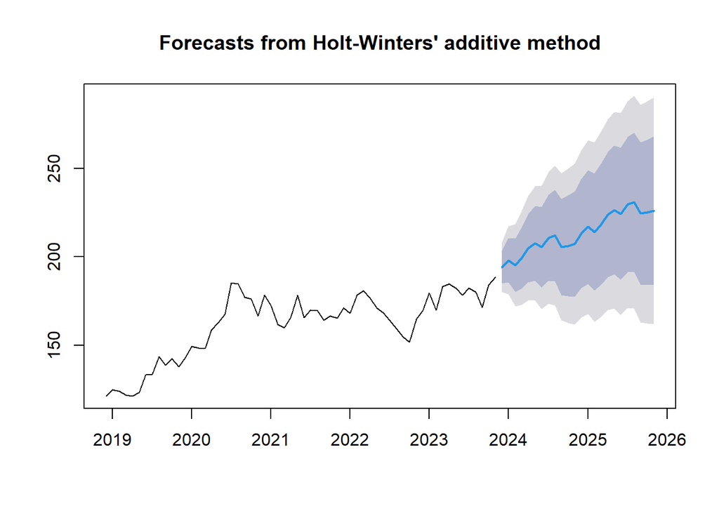

```r
plot(forecast(hw_add))
```

```r
accuracy(hw_add)
```

```
##                     ME     RMSE      MAE        MPE     MAPE      MASE
## Training set -0.403236 6.139429 4.862737 -0.2999758 2.996916 0.2775832
##                     ACF1
## Training set -0.01395089
```

#### Summarize this forecasting technique

###### How good is the accuracy?

- The values for accuracy measure lowest indicating the best forecast.
- Holwinters is a better forecast compared to naive and simple smoothing.

###### Other observation

- Holtwinters appears to be the best forecast considering all the previous forecast methods.
- Also Holtwinters is additive and visually includes seasonality fluctuation hence we can assume till now Hotlwinters
- However, this forecast can still be improved as we can try forecasting using ARIMA models.

```r
adf_test  <- adf.test(TS_win)
print(adf_test)
```

```
##
##  Augmented Dickey-Fuller Test
##
## data:  TS_win
## Dickey-Fuller = -2.378, Lag order = 3, p-value = 0.422
## alternative hypothesis: stationary
```

```r
ndiffs(TS_win)
```

```
## [1] 1
```

The purpose of the tsdisplay() function is typically to provide a visual representation of time series data, which might include plots showing the series data, its seasonal patterns, trend, and other characteristics.

ACF: Displays correlation for all the lags in data. Indicating high correlation with the values in the beginning but the correlation decreases as years pass because there is an increasing trend which indicates increase the difference between initial price and price later in time series indicating strong trend component.

PACF: Displays partial correlation between observations at different time lags after removing influence of different time lag.

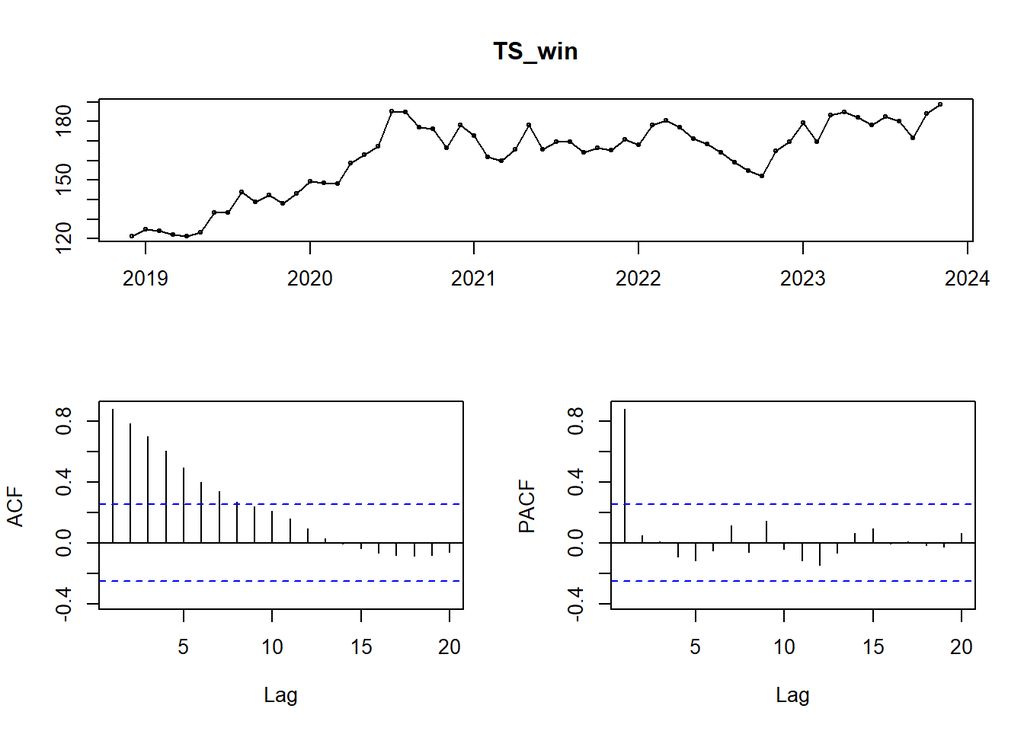

```r
tsdisplay(TS_win)
```

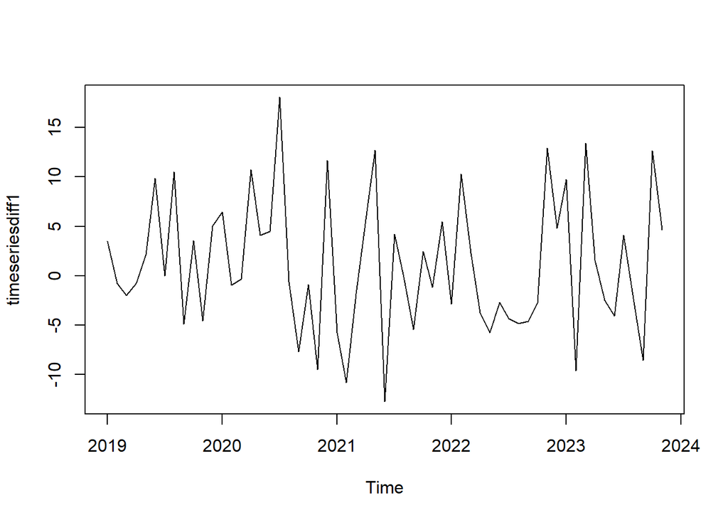

```r
timeseriesdiff1 <- diff(TS_win, differences=1)
plot(timeseriesdiff1)
```

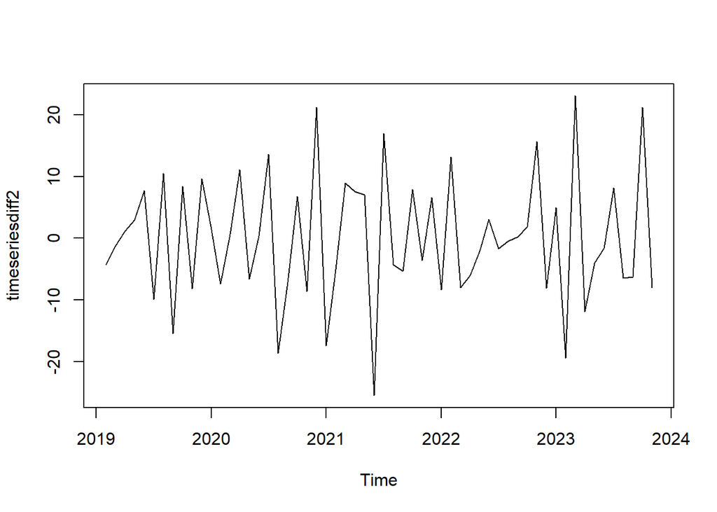

```r
timeseriesdiff2 <- diff(TS_win, differences=2)
plot(timeseriesdiff2)
```

A first-order difference subtracts each value in the time series from the previous value, effectively computing the change from one time point to the next. It’s often used to stabilize the mean of a time series or remove trends and seasonality if they are present.

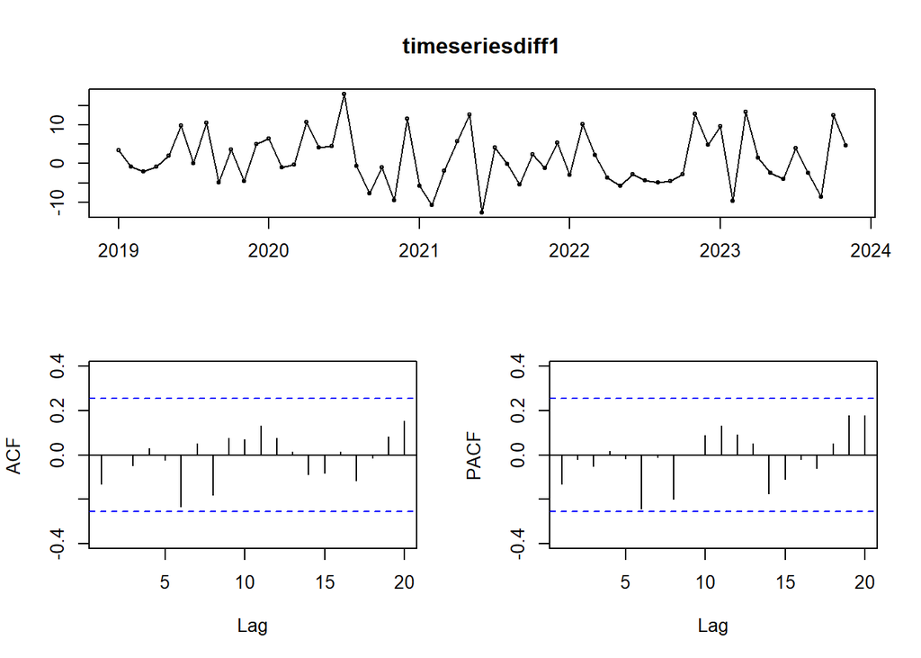

```r
tsdisplay(timeseriesdiff1)
```

The diff() function in R is used to compute differences between consecutive elements in a vector or time series data. The differences parameter specifies the order of differencing, allowing you to create a differenced series by subtracting the value of the series at time t from the value at time t−1.

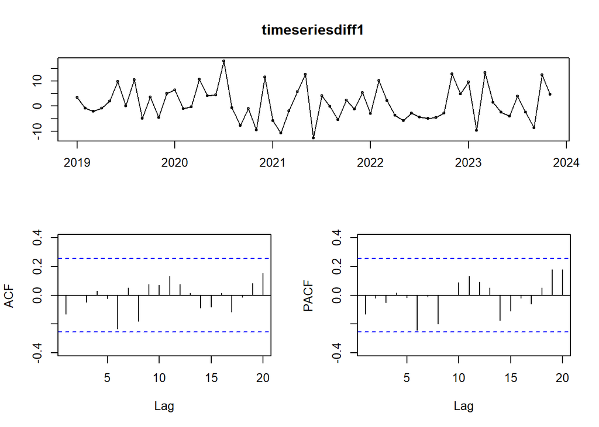

```r
tsdisplay(timeseriesdiff1)
```

```r
auto_fit <- auto.arima(TS_win, trace=TRUE, stepwise = FALSE,approximation = FALSE)
```

```
##
##  ARIMA(0,1,0)                               : 397.7012
##  ARIMA(0,1,0)            with drift         : 398.2084
##  ARIMA(0,1,0)(0,0,1)[12]                    : 399.2171
##  ARIMA(0,1,0)(0,0,1)[12] with drift         : 399.9654
##  ARIMA(0,1,0)(1,0,0)[12]                    : 399.2799
##  ARIMA(0,1,0)(1,0,0)[12] with drift         : 400.0174
##  ARIMA(0,1,0)(1,0,1)[12]                    : 401.2839
##  ARIMA(0,1,0)(1,0,1)[12] with drift         : 402.113
##  ARIMA(0,1,1)                               : 399.2421
##  ARIMA(0,1,1)            with drift         : 399.3949
##  ARIMA(0,1,1)(0,0,1)[12]                    : 400.5367
##  ARIMA(0,1,1)(0,0,1)[12] with drift         : 400.9205
##  ARIMA(0,1,1)(1,0,0)[12]                    : 400.6476
##  ARIMA(0,1,1)(1,0,0)[12] with drift         : 401.032
##  ARIMA(0,1,1)(1,0,1)[12]                    : 402.6594
##  ARIMA(0,1,1)(1,0,1)[12] with drift         : 403.1111
##  ARIMA(0,1,2)                               : 401.4528
##  ARIMA(0,1,2)            with drift         : 401.6859
##  ARIMA(0,1,2)(0,0,1)[12]                    : 402.8318
##  ARIMA(0,1,2)(0,0,1)[12] with drift         : 403.3007
##  ARIMA(0,1,2)(1,0,0)[12]                    : 402.9365
##  ARIMA(0,1,2)(1,0,0)[12] with drift         : 403.4168
##  ARIMA(0,1,2)(1,0,1)[12]                    : 405.0491
##  ARIMA(0,1,2)(1,0,1)[12] with drift         : 405.5629
##  ARIMA(0,1,3)                               : 403.7541
##  ARIMA(0,1,3)            with drift         : 403.8629
##  ARIMA(0,1,3)(0,0,1)[12]                    : 405.2226
##  ARIMA(0,1,3)(0,0,1)[12] with drift         : 405.6441
##  ARIMA(0,1,3)(1,0,0)[12]                    : 405.3276
##  ARIMA(0,1,3)(1,0,0)[12] with drift         : 405.7608
##  ARIMA(0,1,3)(1,0,1)[12]                    : 407.5144
##  ARIMA(0,1,3)(1,0,1)[12] with drift         : 407.8528
##  ARIMA(0,1,4)                               : 405.7631
##  ARIMA(0,1,4)            with drift         : 406.3386
##  ARIMA(0,1,4)(0,0,1)[12]                    : Inf
##  ARIMA(0,1,4)(0,0,1)[12] with drift         : 408.1668
##  ARIMA(0,1,4)(1,0,0)[12]                    : Inf
##  ARIMA(0,1,4)(1,0,0)[12] with drift         : 408.2936
##  ARIMA(0,1,5)                               : 407.9685
```

[output cut: 72 more lines]

```
##  ARIMA(3,1,2)            with drift         : Inf
##  ARIMA(4,1,0)                               : 405.9519
##  ARIMA(4,1,0)            with drift         : 406.4225
##  ARIMA(4,1,0)(0,0,1)[12]                    : 407.4251
##  ARIMA(4,1,0)(0,0,1)[12] with drift         : 408.1866
##  ARIMA(4,1,0)(1,0,0)[12]                    : 407.5509
##  ARIMA(4,1,0)(1,0,0)[12] with drift         : 408.317
##  ARIMA(4,1,1)                               : 408.4337
##  ARIMA(4,1,1)            with drift         : 409.0027
##  ARIMA(5,1,0)                               : 408.4215
##  ARIMA(5,1,0)            with drift         : 408.9897
##
##
##
##  Best model: ARIMA(0,1,0)
```

```r
auto_fit
```

```
## Series: TS_win
## ARIMA(0,1,0)
##
## sigma^2 = 47.83:  log likelihood = -197.82
## AIC=397.63   AICc=397.7   BIC=399.71
```

The ARIMA model with the lowest AIC, AICc, and BIC values, and a smaller sigma^2, is generally considered the best-fitting model among the options you’re comparing.

```r
coefficients <- coef(auto_fit)
print(coefficients)
```

```
## numeric(0)
```

```r
summary(auto_fit)
```

```
## Series: TS_win
## ARIMA(0,1,0)
##
## sigma^2 = 47.83:  log likelihood = -197.82
## AIC=397.63   AICc=397.7   BIC=399.71
##
## Training set error measures:
##                    ME     RMSE      MAE       MPE     MAPE      MASE       ACF1
## Training set 1.127021 6.858342 5.447354 0.6537784 3.298368 0.3109553 -0.1310321
```

auto.arima() function employs an algorithm that searches through various combinations of ARIMA models